# Séance 5 : Avant la séance

Un graphique est un argument. Lequel ferez-vous ?

Thierry Warin, PhD

HEC Montréal

## Plan · Avant le cours

1. Ce qu’il faut faire, et combien de temps cela prend
2. Lire deux articles courts
3. Parcourir la galerie PyStatlas
4. Vérifier les paquets et exécuter un script de la galerie
5. Un premier graphique à produire chez vous
6. Autovérification
7. Utiliser l’IA sur la préparation

## À quoi sert la séance 5

### La stratégie

- Montrer qu’une même affirmation (« l’Amérique crée plus de valeur ») change de réponse selon la **mesure**
- Choisir le graphique qu’un comité de direction lira **sans aide**
- Repérer un graphique qui trompe, même sans mentir

### Le Python

- Lire un script de la galerie **PyStatlas** et l’adapter à nos données
- Construire une figure avec `fig, ax = plt.subplots()` et l’enregistrer avec `savefig`
- Explorer avec **plotly express**

### La méthode

- Partir de la **question**, puis choisir la famille de graphiques
- Titrer par le **message** ; mettre la **statistique** en sous-titre
- Unités, source, étiquetage direct

# Avant la séance

### Un graphique est un argument. Lequel ferez-vous ?

## Ce qu’il faut faire, et combien de temps

| **1** | Lire Anscombe (1973) et Cleveland et McGill (1984), sections 1 et 2 | 45–60 min |
| --- | --- | --- |
| **2** | Parcourir la galerie PyStatlas | 15 min |
| **3** | Vérifier les paquets, exécuter **un** script de la galerie tel quel | 10 min |
| **4** | Produire **un** graphique de `data/pays.csv` | 20 min |
| **5** | Tenter l’autovérification | 15 min |

Le cours suppose les cinq étapes faites. La pratique suppose que vous savez déjà lire un script de la galerie, produire une figure matplotlib et l’**enregistrer**.

## 1 · Lire deux articles courts

**Anscombe, F. J. (1973). Graphs in Statistical Analysis.** *The American Statistician*, 27(1), 17–21. doi.org/10.1080/00031305.1973.10478966

**Cleveland, W. S. et McGill, R. (1984). Graphical Perception.** *JASA*, 79(387), 531–554. doi.org/10.1080/01621459.1984.10478080 — sections 1 et 2 suffisent.

Annotez quatre choses :

| **1** | L’argument d’Anscombe, en une phrase |
| --- | --- |
| **2** | Les six encodages de Cleveland et McGill, dans l’ordre |
| **3** | Un graphique de presse récent qui viole cet ordre |
| **4** | Ce que vous changeriez pour le corriger |

## 2 · Parcourir la galerie PyStatlas

**[warint.github.io/pystatlas/fr](https://warint.github.io/pystatlas/fr/)** — une soixantaine de graphiques statistiques, rangés par famille de questions, chacun avec son code Python complet. Les exemples portent sur de vraies données de sciences sociales : élections, écoles, criminalité, fécondité, régimes politiques.

Ouvrez trois pages de la famille **Distributions** et une de **Corrélation et association**. Pour chacune, notez :

| **1** | La **question** à laquelle le graphique répond, en une phrase |
| --- | --- |
| **2** | La ligne du script qui charge les **données** — celle que vous remplacerez |
| **3** | La **statistique** affichée en sous-titre (n, test, taille d’effet) |
| **4** | Le **titre** : décrit-il le sujet, ou affirme-t-il un message ? |

Le texte des pages est en français ; le code et les figures sont en anglais. Les adapter en français fait partie du travail.

## 3 · Vérifier les paquets, exécuter un script

Depuis la racine du dépôt, `.venv` activé :

```bash
python -c "import matplotlib, seaborn, plotly, scipy, statsmodels; print('ok')"
```

En cas d’erreur : `python -m pip install -r requirements.txt`.

Puis ouvrez le **[graphique en crêtes](https://warint.github.io/pystatlas/fr/distributions/ridgeline/)**, cliquez sur « Copier le code », collez-le dans un fichier `sorties/cretes.py` et exécutez-le **sans rien changer**. Il n’utilise que NumPy, SciPy et statsmodels, déjà installés.

Ce script montre l’évolution de la fécondité des pays, de 1960 à 2010. Quelques scripts chargent leurs données avec **lifelines**, qui n’est pas installé dans le cours : inutile de l’ajouter, en séance c’est précisément la ligne des données que l’on remplace par les nôtres.

## 4 · Un premier graphique, chez vous

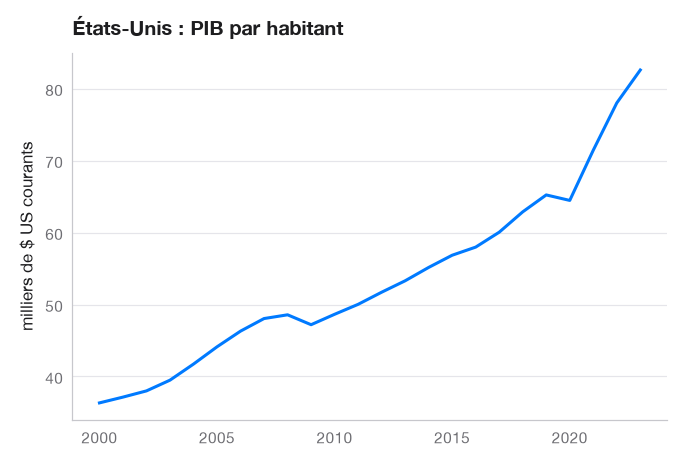

```python
import pandas as pd
import matplotlib.pyplot as plt
from pathlib import Path

plt.style.use("05-representer-les-donnees/pystatlas.mplstyle")
Path("sorties").mkdir(exist_ok=True)
pays = pd.read_csv("data/pays.csv")
usa = pays[pays["iso3"] == "USA"]

fig, ax = plt.subplots(figsize=(6, 4))
ax.plot(usa["annee"], usa["pib_hab_usd"] / 1000)
ax.set_title("États-Unis : PIB par habitant")
ax.set_ylabel("milliers de $ US courants")
fig.savefig("sorties/usa_pib_hab.png")
plt.show()
```

**À faire :** ajoutez le Canada sur la même figure, avec une couleur différente et une étiquette au bout de chaque ligne (`ax.text`). Réécrivez le titre pour qu’il **affirme** quelque chose. Apportez le fichier PNG.

## 5 · Autovérification

Répondez **par écrit** avant le cours. Rien n’est remis, mais le cours suppose que vous avez essayé.

1. Pourquoi Anscombe a-t-il construit quatre jeux de données **identiques** en statistiques résumées ?
2. Classez du plus précis au moins précis : couleur, position, angle, longueur, aire.
3. Une barre peut-elle commencer à 50 ? Une ligne ? Pourquoi la réponse diffère-t-elle ?
4. Dans un script PyStatlas, quels sont les quatre blocs, et lequel changez-vous pour vos données ?
5. Quelle est la différence entre `fig` et `ax` dans `fig, ax = plt.subplots()` ?

## Utiliser l’IA sur la préparation

Votre assistant est un partenaire d’étude, pas un corrigé. Requêtes utiles :

- « Voici le script PyStatlas du nuage de pluie. Explique-moi chaque bloc, ligne par ligne. »
- « Voici un graphique décrit en mots. Selon Cleveland et McGill, quel encodage utilise-t-il et lequel serait plus précis ? »
- « Que mesure le test de Kruskal-Wallis affiché en sous-titre, en deux phrases ? »

> **Règle permanente du cours.** Chaque fois que l’IA intervient dans un travail remis, indiquez ce que vous lui avez demandé et **ce que vous avez vérifié, et comment**.

Les IA génèrent souvent du code seaborn ancien (`distplot`, retiré). Partir d’un script de la galerie, qui s’exécute tel quel, évite ce piège.